# Laboratory 4

Statical Methods for Data Science

N Torelli, G Di Credico, V Gioia

16 November 2022

# Likelihood inference

The likelihood function is
$$L(\theta) = L(\theta; y) = c(y) f_Y(y; \theta) \,\,,$$
where $c(y)>0$ is a proportionality constant that does not depend on $\theta$.

On the basis of the data $y$, $\theta \in \Theta$ is more likely than $\theta' \in \Theta$ as an index of the data generating model if $L(\theta) > L(\theta')$

Note:

- $L(\theta)$ is not a density function (on $\Theta$)
- it is convenient to work with $l(\theta) = \log L(\theta)$
- for independent observations $L(\theta) \propto \prod_{i=1}^{n} f_{Y_i}(y_i; \theta)$ and, up to an additive constant, $l(\theta) = \sum_{i=1}^{n} \log f_{Y_i}(y_i; \theta)$
- The value $\hat \theta$ that maximizes $L(\theta)$ (or $l(\theta)$) is the maximum likelihood estimate (MLE)

## Weibull model

Let $y=(y_{1},\ldots, y_{n})$ a sample of i.i.d. values from a Weibull distribution, $Y \sim \mbox{We}(\gamma, \beta)$, with parameter $\theta=(\gamma, \beta)$ and density function:

$$f (y; \gamma, \beta)= \frac{\gamma}{\beta}\left(\frac{y}{\beta}\right)^{\gamma-1}e^{-(y/\beta)^{\gamma}} , \ \ \ y \geq 0, \ \ \ \gamma, \beta >0,$$
where $\gamma$ is the *shape* parameter and $\beta$ is the *scale* parameter.

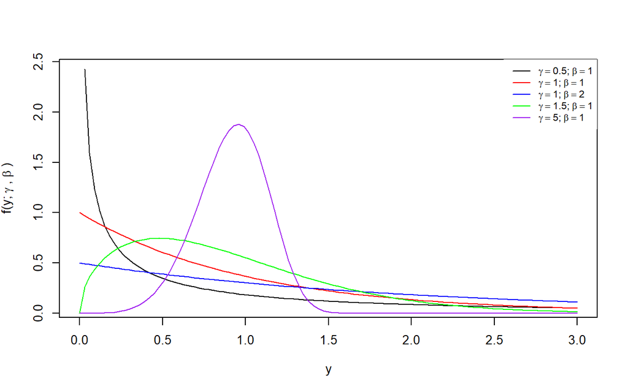

```r
#Plot of the probability density functions of the Weibull distribution, by varying lambda and beta

#shape = 0.5; scale = 1
curve(dweibull(x, shape = 0.5, scale = 1), from = 0, to = 3,
      ylab = expression("f(y;" ~ gamma ~"," ~ beta ~")"), xlab = "y")

#shape = 1; scale = 1
curve(dweibull(x, shape = 1, scale = 1), add = TRUE, col = "red")

#shape = 1; scale = 2
curve(dweibull(x, shape = 1, scale = 2), add = TRUE, col = "blue")

#shape = 1.5; scale = 1
curve(dweibull(x, shape = 1.5, scale = 1), add = TRUE, col = "green")

#shape = 5; scale = 1
curve(dweibull(x, shape = 5, scale = 1), add = TRUE, col = "purple")

# add a legend to plot
legend("topright", legend = c(expression(gamma == 0.5 * ";" ~ beta == 1),
                              expression(gamma == 1 * ";" ~ beta == 1),
                              expression(gamma == 1 * ";" ~ beta == 2),
                              expression(gamma == 1.5 * ";" ~ beta == 1),
                              expression(gamma == 5 * ";" ~ beta == 1)),
       col = c("black", "red", "blue", "green", "purple"), lty = rep(1, 5),
       cex = 0.8, box.lty = 0)
```

Then, the likelihood is defined as:

$$L( \gamma, \beta ;y )=\prod_{i=1}^{n}L_{i}=\prod_{i=1}^{n}f(y_i;\gamma, \beta),$$
and the log-likelihood, up to an additive constant, is defined as:

$$\begin{align*}
l(\gamma, \beta; y)= \log\left( \prod_{i=1}^{n}L_{i}\right)= & \sum_{i=1}^{n} \log f(y_i;\gamma, \beta) \\
= & n\log(\gamma)-n \gamma \log(\beta)+ \gamma\sum_{i=1}^{n}\log(y_{i})-\sum_{i=1}^{n}(y_{i}/\beta)^{\gamma}.
\end{align*}$$

We may write the log-likelihood function in $\mathsf{R}$

**Note: in the following, we consider the negative log-likehood function, since the next Lab we will use some optimizers performing minimization of functions**

Here, we implement a function taking in argument the 2-dimensional parameter and the data, and compute and return the value of the negative log-likehood function.

```r
# Negative log-likelihood function by using the dweibull() function
n_logLik_Weib <- function(param, data){
 -sum(dweibull(data, shape = param[1], scale = param[2], log = TRUE))
}
```

**It’s your turn**

Write the negative log-likelihood by hand, that is use the expression reported above.

```r
# Negative log-likelihood function by hand:
#the last term of the summation, sum(log(y)), is the additive constant which could be removed without affecting inferential results
n_logLik_Weib2 <- function(param, data){
 n <- length(data)
 res <- n * log(param[1]) - n * param[1] * log(param[2]) +
        param[1] * sum(log(data)) - sum((data/param[2])^param[1]) - sum(log(data))
 return(-res)
}
```

## Example: failure times of light bulbs

Suppose now to observe $n = 15$ failure times (expressed in days) of a sample of light bulbs: we assume $y_{1}, \ldots, y_{15} \sim \mbox{We}(\gamma, \beta)$, with $\gamma$ and $\beta$ unknown. Here the observed failure times

```r
# We generate the data by taking for example shape = 7, scale = 155
set.seed(1234)
y <- rweibull(15, shape = 7, scale = 155)
round(y,3)
```

```
##  [1] 173.187 139.334 140.205 139.261 118.176 138.105 193.096 163.589 136.288
## [10] 146.226 134.261 144.331 160.262 107.985 159.651
```

**Exercise**: By using the data, and having fixed a value for the shape and the scale parameter, check whether the two negative log-likelihood functions built using the **dweibull**() function and by hand return the same value.

```r
# Check whether n_logLik_Weib and n_logLik_Weib2 provide the same results
n_logLik_Weib(param = c(5, 125), y)
```

```
## [1] 79.35416
```

```r
n_logLik_Weib2(param = c(5, 125), y)
```

```
## [1] 79.35416
```

We need to estimate the shape and the scale parameter via maximum likelihood estimation. Preliminary, we inspect the log-likelihood function through **contour** plots (or alternatively via the **image**() function).

Step to build the plot:

- Define a grid of values for the parameters (we will use the **expand.grid**() function)
- obtain the log-likelihood values for each point of the grid (Remember to change the sign to the negative log-likelihood)
- Define the levels of the confidence regions
- Use the contour function or the image function to plot the relative log-likelihood, that is $l(\theta) - l(\hat \theta)$, with $\theta=(\gamma, \beta)^\top$

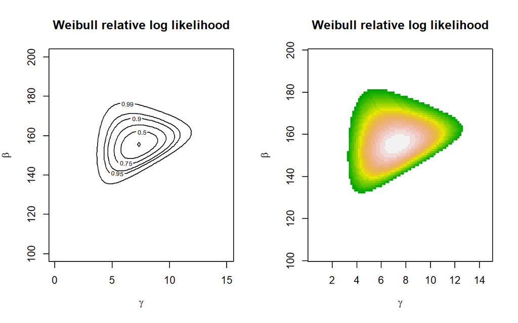

```r
# Define a parameter grid to plot the log-likelihood
gamma <- seq(0.1, 15, length = 100)
beta <- seq(100, 200, length = 100)
parvalues <- expand.grid(gamma, beta)

# obtain the log-likelihood values  for each point of the grid
n_llikvalues <- apply(parvalues, 1, n_logLik_Weib, data = y)
llikvalues <- matrix(-n_llikvalues,
                     nrow = length(gamma), ncol = length(beta),
                     byrow = FALSE)


# Define the confidence levels
conf_levels <- c(0, 0.5, 0.75, 0.9, 0.95, 0.99)

par(mfrow = c(1, 2))
# contour plot
contour(gamma, beta, llikvalues - max(llikvalues),
        levels = -qchisq(conf_levels, 2)/2,
        xlab = expression(gamma),
        ylab = expression(beta),
        labels = as.character(conf_levels))
title("Weibull relative log likelihood")

# image plot
image(gamma, beta, llikvalues - max(llikvalues),
      zlim = c(-6, 0),
      col = terrain.colors(20), xlab = expression(gamma),
      ylab = expression(beta))
title("Weibull relative log likelihood")
```

### Parameter estimates

We may compute the maximum likelihood estimates $\hat{\gamma}, \hat{\beta}$ by equating at zero the score, or in other words by solving the score equations:

$$\begin{align*}
\frac{\partial}{\partial \gamma}l(\gamma, \beta; y)= & \frac{n}{\gamma}-n \log(\beta)+ \sum_{i=1}^{n}\log(y_{i})-\sum_{i=1}^{n}(y_{i}/\beta)^{\gamma}\log( y_{i}/\beta) = 0 \\
\frac{\partial}{\partial \beta}l(\gamma, \beta; y)= & -\frac{n}{\beta} \gamma + \frac{\gamma} {\beta^{\gamma+1}} \sum_{i=1}^{n} y_{i}^{\gamma} = 0
\end{align*}$$

Solving the second equation we get the constrained estimate $\beta_{\gamma}= (\sum_{i=1}^{n} y^{\gamma}_{i}/n)^{1/\gamma}$. Substituting it in the first equation, we get

$$\frac{n}{\gamma}+\sum_{i=1}^{n} \log (y_{i})-n \frac{\sum_{i} y^{\gamma}_{i}\log(y_{i})}{\sum_{i} y^{\gamma}_{i}} =0$$

The last equation needs to be solved numerically.

**EXERCISE FROM LAB 3**

Write the score function, namely the partial derivative of $\ell(\theta)$ w.r.t. to $\gamma$ (hint: substitute $\beta_{\gamma}$).

```r
# Score function (derivatives of l(theta) w.r.t. to gamma evaluated in betahat )
logLik_score_g <- function(x, data){
 n <- length(data)
 res <- n/x + sum(log(data)) - n*(sum(data^x*log(data))/(sum(data^x)))
 return(res)
}
```

```r
# MLE of gamma: solve the lok-likelihood equation based on the previous score by using the uniroot function
gammahat <- uniroot(logLik_score_g, c(1e-5, 15), data = y)$root
gammahat
```

```
## [1] 7.289321
```

```r
# MLE of beta, for a fixed value of gamma (the MLE of gamma)
betahat <- mean(y^gammahat)^(1/gammahat)
betahat
```

```
## [1] 155.3338
```

```r
# Check if the score is (0,0) in the MLE
library(numDeriv)
grad(c(gammahat, betahat), func = n_logLik_Weib, data = y)
```

```
## [1]  1.564041e-05 -2.112082e-12
```

Of course, we are interested in assessing the variability of our MLE estimator. Let $\theta=(\gamma, \beta)$ be the 2-dimensional parameter vector. At this purpose, we may compute the **observed information** matrix
$$J(\theta; y)=- \frac{\partial^{2} l( \theta;y)}{ \partial \theta \partial \theta^{T}}.$$

$$\frac{\partial^{2} l( \theta;y)}{\partial \gamma^2}=-\frac{n}{\gamma^2}-\sum_{i=1}^{n}\Big(\frac{y_i}{\beta}\Big)^\gamma \Bigg\{\log\Big(\frac{y_i}{\beta}\Big) \Bigg\}^2$$

$$\frac{\partial^{2} l( \theta;y)}{\partial \gamma \partial \beta}=-\frac{n}{\beta}+\sum_{i=1}^{n}\Big(\frac{y_i^\gamma}{\beta^{\gamma+1}} \Big)\Big\{\gamma \log\Big(\frac{y_i}{\beta}\Big)+1 \Big\}$$
$$\frac{\partial^{2} l( \theta;y)}{\partial \beta^2}= \frac{n\gamma}{\beta^2}-\frac{\gamma(\gamma+1)}{\beta^{\gamma+2}} \sum_{i=1}^{n}y_i^\gamma$$

Taking its inverse, evaluated in $(\hat{\gamma}, \hat{\beta})$, we obtain an estimate for the variance of our estimators.

```r
n <- length(y)
# observed information matrix evaluated in the MLE
jhat <- matrix(NA, 2, 2)
jhat[1,1] <- n/gammahat^2 + sum((y/betahat)^gammahat*(log(y/betahat)^2))
jhat[1,2] <- jhat[2,1] <- n/betahat - sum(y^gammahat/(betahat^(gammahat+1))*(gammahat*log(y/betahat)+1))
jhat[2,2] <- -n*gammahat/(betahat^2) + gammahat*(gammahat+1)*sum(y^gammahat)/(betahat^(gammahat+2))

jhat
```

```
##             [,1]        [,2]
## [1,]  0.60641358 -0.04736006
## [2,] -0.04736006  0.03303187
```

```r
# Check by using the hessian function of the numDeriv package
hessian(c(gammahat, betahat), func=n_logLik_Weib, data=y)
```

```
##             [,1]        [,2]
## [1,]  0.60641358 -0.04736006
## [2,] -0.04736006  0.03303187
```

```r
# Estimate of the std.err of the MLE estimators
mle.se <- sqrt(diag(solve(jhat)))
mle.se
```

```
## [1] 1.362709 5.838764
```

#### Confidence region

We will see confidence regions for $\theta$, with $dim(\theta)=p$, based on

- (log) - likelihood ratio test (LRT) $W(\theta) = 2(l(\hat \theta)- l(\theta)) \stackrel{\cdot}\sim \chi_{p}$; In such a case a confidence region with level $1-\alpha$ is
  $$\{\theta: W(\theta) < \chi_{p; 1-\alpha} \} = \{\theta: l(\theta) > l(\hat \theta) -\frac{1}{2}\chi_{p; 1-\alpha} \}$$
- Wald test is based on the quadratic approximation of the log-likelihood function: $W_e(\theta) \approx -\frac{1}{2}(\hat \theta - \theta)^\top j(\hat \theta) (\hat \theta -\theta)$, which is asimptotically distributed as $W(\theta)$, that is $\chi_{p}$. In such a case a confidence region with level $1-\alpha$ is
  $$\{\theta: W_e(\theta) < \chi_{p; 1-\alpha} \}$$

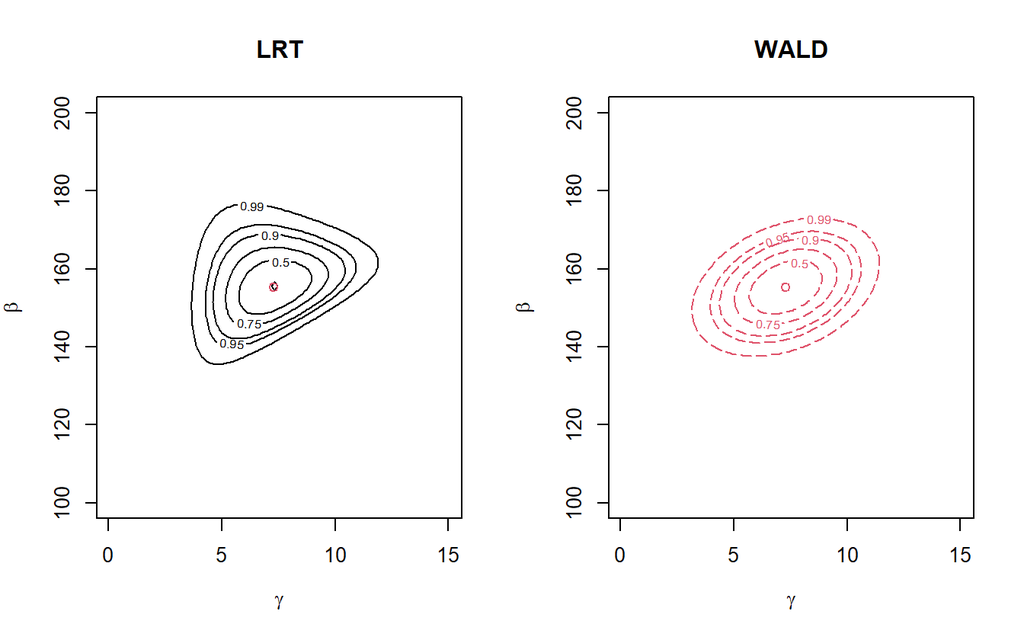

```r
par(mfrow=c(1,2))
contour(gamma,beta,llikvalues-max(llikvalues),
ylab=expression(beta),xlab=expression(gamma),
levels=-qchisq(conf_levels,2)/2,main='LRT',
labels=as.character(conf_levels))
points(gammahat,betahat,col=2)

weib.y.mle <- c(gammahat, betahat)
waldvalues<-apply(parvalues,1,function(par)
                  -.5*t(as.matrix(par-weib.y.mle))%*%jhat%*%
                  as.matrix(par-weib.y.mle))

waldvalues<-matrix(waldvalues,nrow=length(gamma),
                   ncol=length(beta),byrow=F)
contour(gamma,beta,waldvalues,ylab=expression(beta),
xlab=expression(gamma),levels=-qchisq(conf_levels,2)/2,
labels=as.character(conf_levels),col=2,main='WALD',
lty='longdash')
points(gammahat,betahat,col=2)
```

Note on LRT:

- all the points belongs to the parametric space
- invariant w.r.t. reparametrisations
- usually better empirical coverage

**Exercise 1**

Compute the MLE and the observed information matrix for a gamma model with parameters shape $\alpha$ and scale $\beta$. Recall that for $Y\sim \rm{Ga}(\alpha,\beta)$ the probability density function is
$$f_Y(y; \alpha, \beta) = \frac{1}{\beta^\alpha \Gamma(\alpha)} y^{\alpha - 1} e^{-y/\beta}, \ \ \ y \geq 0, \ \ \ \alpha, \beta >0,$$

## Numerical optimization

So far, we used $\mathsf{R}$ simply as a pocket calculator, computing MLE and the variance of our estimators *analytically*, and then obtaining the numerical values just plugging into the formulas the inputs. However, remind the MLE for $\gamma$, where the equation:

$$\frac{n}{\gamma}+\sum_{i=1}^{n} \log (y_{i})-n \frac{\sum_{i} y^{\gamma}_{i}\log(y_{i})}{\sum_{i} y^{\gamma}_{i}} =0$$
does not have an analytical solution. Many times we do not have a closed form for MLE estimates and we may need **numerical optimization**. $\mathsf{R}$ provides various functions for performing numerical methods:

- $\mathsf{nlm()}$: minimizes a function using a Newton-type algorithm. It needs a starting value and does not allow constraints on the parameters. It is usually fast and reliable. It returns the ML estimate $\hat{\theta}$ ($\mathsf{estimate}$), the value of the likelihood $-l(\hat{\theta})$ ($\mathsf{minimum}$) and the hessian ($\mathsf{hessian}$), if $\mathsf{hessian = TRUE}$.
- $\mathsf{optim()}$: minimizes a function using Nelder-Mead, quasi-Newton and conjugate gradients algorithms. It includes an option for box-constrained optimization, and it requires a starting value. It returns the ML estimate $\hat{\theta}$ ($\mathsf{par}$) and the value of the likelihood $-l(\hat{\theta})$ ($\mathsf{value}$) and the hessian ($\mathsf{hessian}$), if $\mathsf{hessian = TRUE}$. You also can maximize the function by using $\mathsf{fnscale = -1}$ in $\mathsf{control}$ argument.
- $\mathsf{nlminb()}$: often is more stable, robust and reliable than $\mathsf{optim}$ (in particular with “nasty” functions). It performs only minimization and does not yield numerical derivatives as output. It returns the ML estimate $\hat{\theta}$ ($\mathsf{par}$) and the value of the likelihood $-l(\hat{\theta})$ ($\mathsf{objective}$).
- $\mathsf{optimize()}$: by using a combination of golden section search and successive parabolic interpolation, searches in an interval for a minimum or a maximum (if $\mathsf{maximum=TRUE}$) of a function. It returns the ML estimate $\hat{\theta}$ ($\mathsf{minimum}$) and the value of the likelihood $l(\hat{\theta})$ ($\mathsf{objective}$). Drawback: suited only for one-dimensional parameter.

There exists others functions. I prefer https://cran.r-project.org/web/packages/ucminf/index.html

```r
# Numerical optimization of the log-likelihood function

# By using nlm function
#Staring values near to MLE estimate
weib.nlm_start1 <- nlm(f = n_logLik_Weib, p = c(5, 160), data = y, hessian = TRUE)
weib.nlm_start1
```

```
## $minimum
## [1] 67.4824
##
## $estimate
## [1]   7.289283 155.333712
##
## $gradient
## [1]  1.111246e-06 -1.282633e-07
##
## $hessian
##             [,1]        [,2]
## [1,]  0.60639337 -0.04728086
## [2,] -0.04728086  0.03299776
##
## $code
## [1] 1
##
## $iterations
## [1] 10
```

```r
#Staring values far to MLE estimate
weib.nlm_start2 <- nlm(f = n_logLik_Weib, p = c(0.1, 0.1), data = y, hessian = TRUE)
weib.nlm_start2
```

```
## $minimum
## [1] 67.4824
##
## $estimate
## [1]   7.289276 155.333705
##
## $gradient
## [1] -2.544171e-06 -5.040877e-08
##
## $hessian
##             [,1]        [,2]
## [1,]  0.60639377 -0.04728075
## [2,] -0.04728075  0.03299770
##
## $code
## [1] 1
##
## $iterations
## [1] 27
```

```r
# By using optim function
#Starting values near to MLE estimate
weib.optim_start1 <- optim(par = c(5, 160), fn= n_logLik_Weib, data = y, hessian = TRUE,
                         method = "L-BFGS-B", lower = rep(1e-7,2), upper = rep(Inf,2))
weib.optim_start1
```

```
## $par
## [1]   7.289289 155.333802
##
## $value
## [1] 67.4824
##
## $counts
## function gradient
##       11       11
##
## $convergence
## [1] 0
##
## $message
## [1] "CONVERGENCE: REL_REDUCTION_OF_F <= FACTR*EPSMCH"
##
## $hessian
##             [,1]        [,2]
## [1,]  0.60641601 -0.04735972
## [2,] -0.04735972  0.03303161
```

```r
#Staring values far to MLE estimate
weib.optim_start2 <- optim(par = c(0.1, 0.1), fn = n_logLik_Weib, data = y, hessian = TRUE,
                         method = "L-BFGS-B", lower = rep(1e-7, 2), upper = rep(Inf,2))
weib.optim_start2
```

```
## $par
## [1]   7.289292 155.333808
##
## $value
## [1] 67.4824
##
## $counts
## function gradient
##       35       35
##
## $convergence
## [1] 0
##
## $message
## [1] "CONVERGENCE: REL_REDUCTION_OF_F <= FACTR*EPSMCH"
##
## $hessian
##             [,1]        [,2]
## [1,]  0.60641575 -0.04735971
## [2,] -0.04735971  0.03303163
```

### Reparametrizations

To avoid numerical problems, it is better to work with ’ **reparametrization**:

$$\psi = \psi(\theta)=(\psi_1 = \log (\gamma), \psi_2 = \log(\beta)).$$

Generally, for numerical purposes, it is convenient to reparameterize the model in such a way that the new parameter space is unbounded. In this case $\phi \in {\rm R}^2$. At such point, the parameters estimates will be expressed in the log-scale, and we need to re-express them in the original scale. Obviously, $\theta = \theta(\psi)= (e^{\psi_1}, e^{\psi_2})$).

```r
# Reparameterization
theta <- function(omega) exp(omega)

# Negative log-likelihood
n_logLik_Weib_rep <- function(param, data) n_logLik_Weib(theta(param), data)

# Optimize the log-likelihood function by using nlm (also here the are some warnings but the algorithm works)
weib_nlm_start3_rep <- nlm(f = n_logLik_Weib_rep, p = c(0, 0), data = y)
weib_nlm_start3_rep
```

```
## $minimum
## [1] 67.4824
##
## $estimate
## [1] 1.986401 5.045573
##
## $gradient
## [1] -1.860059e-07 -1.101251e-06
##
## $code
## [1] 1
##
## $iterations
## [1] 34
```

```r
# Check
theta(weib_nlm_start3_rep$estimate)
```

```
## [1]   7.289249 155.333353
```

```r
weib.nlm_start1$estimate
```

```
## [1]   7.289283 155.333712
```

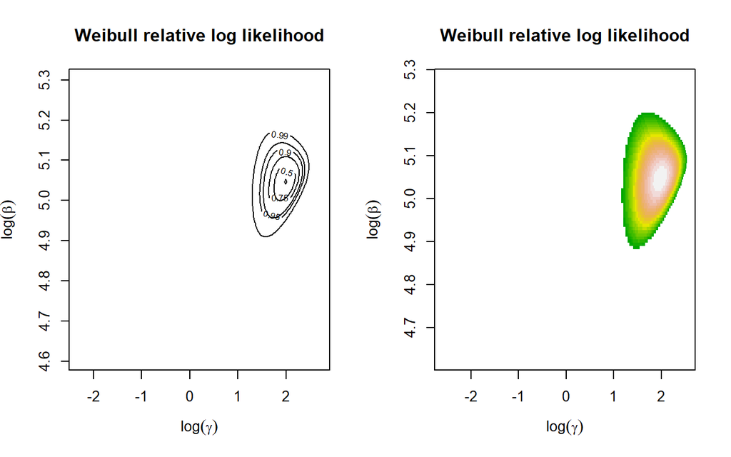

```r
gamma <- seq(0.1, 15, length = 100)
beta <- seq(100, 200, length = 100)
parvalues <- expand.grid(log(gamma), log(beta))

# obtain the log-likelihood values  for each point of the grid
n_llikvalues <- apply(parvalues, 1, n_logLik_Weib_rep, data = y)
llikvalues <- matrix(-n_llikvalues,
                     nrow = length(gamma), ncol = length(beta),
                     byrow = FALSE)


# Define the confidence levels
conf_levels <- c(0, 0.5, 0.75, 0.9, 0.95, 0.99)

par(mfrow = c(1, 2))
# contour plot
contour(log(gamma), log(beta), llikvalues - max(llikvalues),
        levels = -qchisq(conf_levels, 2)/2,
        xlab = expression(log(gamma)),
        ylab = expression(log(beta)),
        labels = as.character(conf_levels))
title("Weibull relative log likelihood")

# image plot
image(log(gamma), log(beta), llikvalues - max(llikvalues),
      zlim = c(-6, 0),
      col = terrain.colors(20),xlab = expression(log(gamma)),
        ylab = expression(log(beta)))
title("Weibull relative log likelihood")
```

```r
# Try to use also nlminb
```

The $\mathsf{optim()}$ function provides a lot of numerical methods, such us Nelder-Mead, quasi-Newton, conjugate-gradient methods and simulated annealings. As a drawback, the user has to set up very carefully the initial parameters and the adopted method, since the final solution may be quite sensitive to these choices…To compute the observed information, the function $\mathsf{optimHess()}$ computes numerical derivatives of generic functions, if $\mathsf{hessian = TRUE}$ was forgotten in $\mathsf{optim()}$.

```r
# Working on the reparameterization
# Log-likelihood optimization by using optim:
# starting values = c(1,20), quasi-Newton Method
weib_optim_start3_rep_qn <- optim(par = c(1, 20), fn = n_logLik_Weib_rep,
                             method = "BFGS", data=y)


# starting values = c(1,6), conjugate-gradient Method
weib_optim_start3_rep_CG <- optim(par = c(1, 6), fn = n_logLik_Weib_rep,
                             method = "CG", data = y)

# check
theta(weib_optim_start3_rep_qn$par)
```

```
## [1]   7.289323 155.333973
```

```r
theta(weib_optim_start3_rep_CG$par)
```

```
## [1]   7.28905 155.33369
```

```r
weib.nlm_start1$estimate
```

```
## [1]   7.289283 155.333712
```

```r
# Check the hessian
optimHess(theta(weib_optim_start3_rep_qn$par), n_logLik_Weib, data = y)
```

```
##             [,1]        [,2]
## [1,]  0.60641002 -0.04735869
## [2,] -0.04735869  0.03303163
```

```r
jhat
```

```
##             [,1]        [,2]
## [1,]  0.60641358 -0.04736006
## [2,] -0.04736006  0.03303187
```

## Extra: Profile likelihood

In practical situations, some components of the parameter vector $\theta$ are more important than others; essentially, in such situations it is of interest for us making inference only on those subgroups of parameters. In the Weibull case, we could treat $\gamma$ as the *parameter of interest* and $\beta$ as the *nuisance parameter*. We may then define the profile **log-likelihood**:

$$l_{P}(\gamma) = \underset{\beta}{\max}\ l(\gamma, \beta; y)= l(\gamma, \hat{\beta}_{\gamma}; y),$$
where $\hat{\beta}_{\gamma}$ is the *constrained* MLE for $\beta$, with $\gamma$ fixed. Some issues deserve a quick consideration:

- the profile log-likelihood is simply the log-likelihood for the bidimensional parameter $\theta$, with the nuisance component $\beta$ replaced by $\hat{\beta}_{\gamma}= (\sum_{i=1}^{n} y^{\gamma}_{i}/n)^{1/\gamma}$.
- $l_{P}$ is not a *genuine* likelihood. However, it has some nice features which ease to work with it.

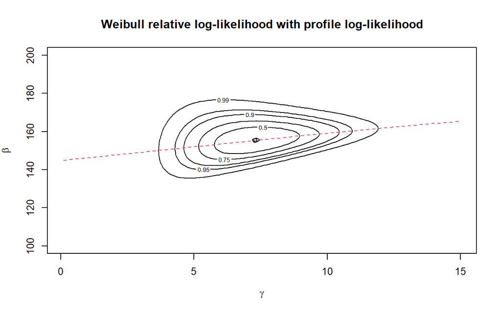

```r
weib.y.mle<- optim(par = c(1,1), fn = n_logLik_Weib, hessian = TRUE,
                   method = "L-BFGS-B", data = y,
                   lower = rep(1e-7, 2), upper = rep(Inf, 2) )

# We can visualize the profile log-likelihood directly in the contour plot of the log-likelihood
gamma <- seq(0.1, 15, length = 100)
beta <- seq(100, 200, length = 100)
parvalues <- expand.grid(gamma, beta)
llikvalues <- apply(parvalues, 1, n_logLik_Weib, data = y)
llikvalues <- matrix(-llikvalues, nrow = length(gamma),
                     ncol = length(beta), byrow = FALSE)

conf.levels <- c(0, 0.5, 0.75, 0.9, 0.95, 0.99)

par(mfrow=c(1,1))
contour(gamma, beta, llikvalues - max(llikvalues),
        levels = -qchisq(conf.levels, 2)/2,
        xlab = expression(gamma),
        ylab = expression(beta),
        labels = as.character(conf_levels))


beta.gamma <- sapply(gamma, function(x) mean(y^x)^(1/x))
# line of the constrained estimate
lines(gamma, beta.gamma, lty = "dashed", col = 2)
points(weib.y.mle$par[1],weib.y.mle$par[2])
title("Weibull relative log-likelihood with profile log-likelihood")
```

In some sense, we *reduced the dimension* of the problem, and we acknowledged that we may work with a one-dimensional likelihood evaluated in the constrained value $\hat{\beta}_{\gamma}$ for the nuisance component. Then, we may now compute some **deviance confidence intervals** with level $1-\alpha$ as:

$$\{ \gamma: l_{P}(\gamma) \ge l_{P}(\hat{\gamma})-\frac{1}{2}\chi^{2}_{1; 1-\alpha} \},$$
where $\chi^{2}_{1; 1-\alpha}$ is the $1-\alpha$-th quantile of a chi-squared distribution with 1 d.f, the asymptotic distribution for the **profile likelihood-ratio test statistic**:

$$W_{P}(\gamma)=2 \{ l_{P}(\hat{\gamma})-l_{P}(\gamma) \}.$$

```r
# profile log-likelihood
n_logLik_Weib_profile <- function(gamma, data){
 beta.gamma <- mean(data^gamma)^(1/gamma)
 n_logLik_Weib(c(gamma, beta.gamma), data)
}

# vectorize the function with respect to gamma
n_logLik_Weib_profile_v <- Vectorize(n_logLik_Weib_profile, 'gamma')

# Vectorized function allows to compute the function in a vector of points and get the corresponding output results. So
n_logLik_Weib_profile(c(5,6,7), data = y) # wrong
```

```
## [1] 156639624
```

```r
#since return the log-likelihood evaluated in c(5,6)
n_logLik_Weib(c(5,6), data=y)
```

```
## [1] 156639624
```

```r
n_logLik_Weib_profile_v(c(5,6,7), data = y) # correct
```

```
## [1] 69.12128 67.96647 67.50531
```

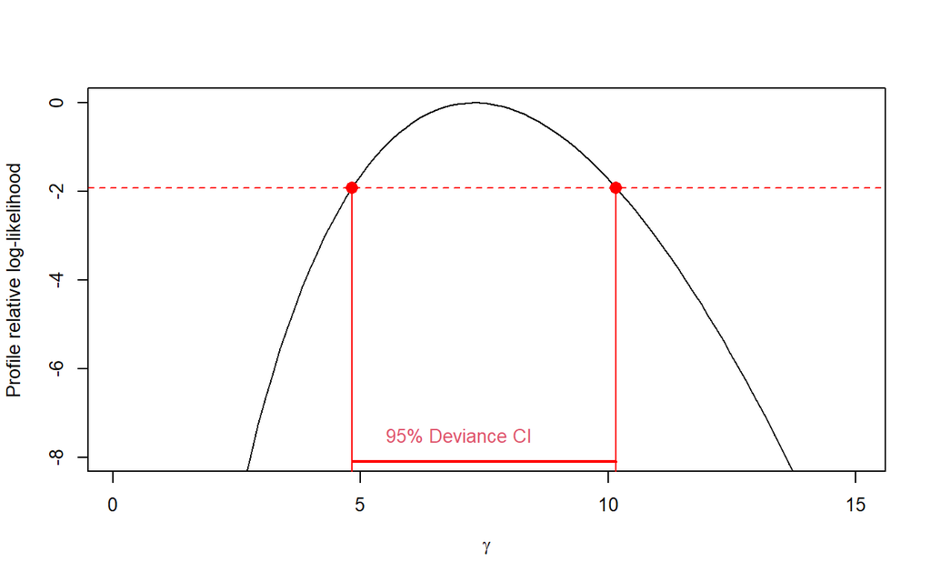

```r
# Plot the relative profile log-likelihood
plot(function(x) -n_logLik_Weib_profile_v(x, data = y) + weib.y.mle$value,
     from = 0.1, to =15, xlab = expression(gamma),
     ylab = "Profile relative log-likelihood", ylim =  c(-8,0))

# choose the confidence level
conf.level <- 0.95
#Obtaining the upper and the lower limits of the deviance confidence interval
abline(h = -qchisq(conf.level,1)/2, lty = "dashed", col = "red")

# Find the numerical values by using the uniroot function
lrt.ci1 <- uniroot(function(x) -n_logLik_Weib_profile_v(x, data = y) + weib.y.mle$value +
                   qchisq(conf.level,1)/2,
                   c(1e-7,weib.y.mle$par[1]))$root
lrt.ci <- c(lrt.ci1, uniroot(function(x) -n_logLik_Weib_profile_v(x, data = y) +  weib.y.mle$value +
                   qchisq(conf.level,1)/2,
                   c(weib.y.mle$par[1],15))$root)

# Plotting some quantities in the relative profile log-likelihood plot
segments(lrt.ci[1], -qchisq(conf.level,1)/2,
         lrt.ci[1], -n_logLik_Weib_profile_v(lrt.ci[1], data = y), col = "red")
segments(lrt.ci[2], - qchisq(conf.level,1)/2,
         lrt.ci[2], -n_logLik_Weib_profile_v(lrt.ci[2], data = y), col = "red")

points(lrt.ci[1],-qchisq(conf.level,1)/2, pch=16, col="red", cex=1.5)
points(lrt.ci[2],-qchisq(conf.level,1)/2, pch=16, col="red", cex=1.5)

segments(lrt.ci[1], -8.1, lrt.ci[2], -8.1, col = "red", lty = 1, lwd =2 )
text(7,-7.5, "95% Deviance CI", col = 2)
```

**Extra Exercise 2** The **Wald confidence interval** with level $1-\alpha$ is defined as:

$$\hat{\gamma} \pm z_{1-\alpha/2}j_{P}(\hat{\gamma})^{-1/2}.$$
Compute the Wald confidence interval of level 0.95, plot the results, and evaluate via simulation the empirical coverage of the confidence interval.

**Extra Exercise 3** Repeat the steps above —write the profile log-likelihood, plot it and find the deviance confidence intervals— considering this time $\gamma$ as a nuisance parameter and $\beta$ as the parameter of interest.